# 2. Introduction to {ggplot2}

Britta Schumacher

Last updated: 10 August, 2022

*FIRST*: Many thanks to Alison Horst for her gorgeous [aRt](https://github.com/allisonhorst/stats-illustrations).

# Data Visualization with `ggplot2`

### What is `ggplot2`?

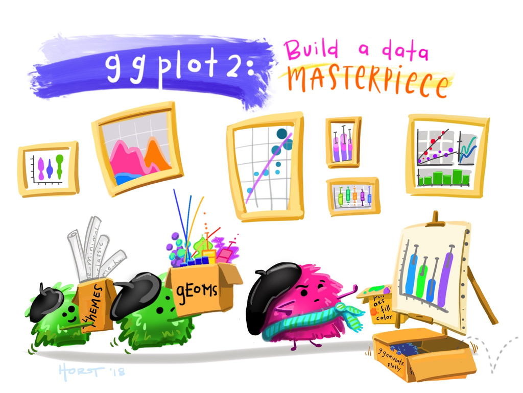

Artwork by the *incredible* Alison Horst

`ggplot2` is the bread and butter of data visualization; it takes clean, organized, manipulated data, and (with your direction) builds beautiful, & more importantly, *communicative*, plots. `ggplot2` is based on the *grammar of graphics*, which asserts that we can build every graph from the same few components: 1) a clean and tidy **data set**; 2) a set of **geoms** that map out data points; and 3) a **coordinate system** (in the broadest sense; i.e., how will the data be mapped onto a graphical surface).

To actually display data values, we map out our variables to aesthetic things like **size**, **color**, and **x** and **y** locations; we also tell `ggplot2` the type of visualization we are interested in building (e.g., bar graph, box plot, line graph, density plots, etc.). `ggplot2` opens up [data science](https://r4ds.had.co.nz/introduction.html) to broader audiences and helps all of us communicate our science. Download [this](https://www.rstudio.com/wp-content/uploads/2015/03/ggplot2-cheatsheet.pdf) cheat sheet and save it somewhere accessible–it’s an incredible tool to refer back to!

`ggplot2` works with `data.frames`, the data type we built in our previous `tidyverse` workshop. The data we feed into `ggplot2` consists of rows and columns that “live peacefully” together in a tidy `data.frame`. This means, often, we need to do some data cleaning up front to get our data into the **tidy** format we need for visualization.

# Now let’s practice on some REAL*ish* data!

### Load the tidyverse and any additional required packages:

```r
library(tidyverse)
g <- read.csv("data/gapminder_data.csv")
```

### Explore:

We should first familiarize ourselves with the data.

```r
dim(g) # view dimensions of the df
head(g) # view first 10 rows of df
tail(g) # view last 10 rows of df
str(g) # view data structure of df
colnames(g) # view the columns of df
```

### Wrangle:

This dataset is **pretty big**–we’ll want to wrangle it so that it only includes the information that we’re interested in. We will:

1. filter for the African continent
2. select relevant columns of data
3. rename columns
4. create new columns.

Let’s create an efficient workflow by combining **ALL** of these data wrangling steps into one; i.e., let’s review harnessing the great POWERS of `tidyverse`!

```r
africa_simple <- g %>%
  filter(continent %in% c("Africa")) %>%
  select(1:3,lifeExp, gdpPercap) %>%
  rename(gdp = gdpPercap) %>%
  mutate(income_class = case_when(
              gdp  < 1000 ~ "low",
              (gdp >= 1000 & gdp <= 6000) ~ "middle",
              gdp > 6000 ~ "high"))

# recall how we save data
saveRDS(africa_simple, "./out-data/africa-tidy.RDS")
```

With this simplified and cleaned data set, we’re ready to explore! Let’s first isolate data we want to visualize by:

1. selecting Malawi, Tanzania, Mozambique, Zimbabwe, and Zambia
2. grouping observations by country
3. finding the average life expectancy, and per capita GDP for each country combination

```r
malawi <- africa_simple %>%
  filter(country %in% c("Malawi", "Tanzania", "Mozambique", "Zimbabwe", "Zambia")) %>%
  group_by(country) %>%
  summarize(ave_life = ave(lifeExp),
            ave_GDP = ave(gdp)) %>%
  unique()
malawi_long <- africa_simple %>%
  filter(country %in% c("Malawi", "Tanzania", "Mozambique", "Zimbabwe", "Zambia"))
```

### Column graph

Now that we have our data summarised and in tidy format, we’re ready to make a plot! We want to:

1. create a column graph showing the summarised data by country
2. make it pretty

**Note:** Only the first 3 lines of the following code are necessary to make the plot. Everything else simply modifies the appearance and make it a bit more presentable. There are *tons* of ways to customize plots – we explore only a few options below.

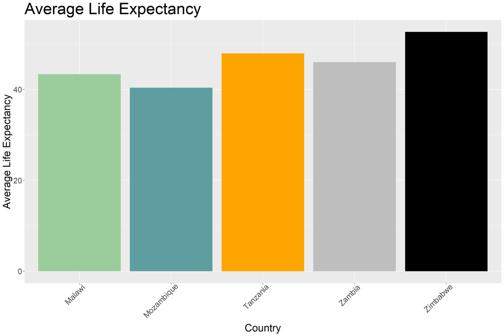

```r
ggplot(malawi, aes(x = country, y = ave_life, fill = country)) + # fill = summary variables
  geom_col(position = "dodge") + # separate columns for each age group
  ggtitle("Average Life Expectancy") + # add a title
  labs(x = "Country", y = "Average Life Expectancy", fill = "") + # add labels on the axes and legend
  scale_fill_manual(values = c("darkseagreen3", "cadetblue", "orange","grey", "black")) + # change colors and names
  theme(legend.position = "none",
        axis.text = element_text(size = 17),
        axis.title = element_text(size = 22),
        plot.title = element_text(size = 34),
        axis.text.x = element_text(angle = 45, hjust = 0.9)) # change the angle of the x axis text, change the horizontal adjustment
```

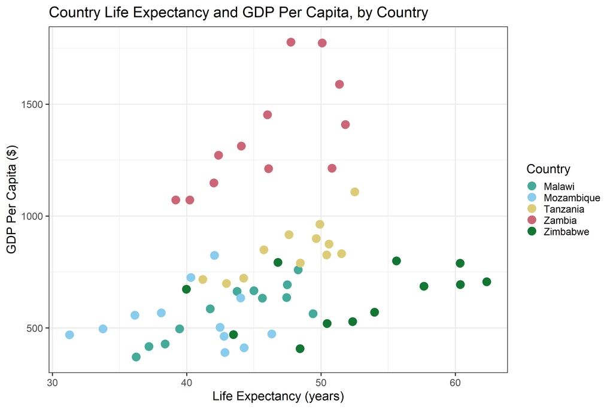

```r
ggplot(malawi_long) + # fill = summary variables
  geom_point(aes(x = lifeExp, y = gdp, color = country), size = 7) + # separate columns for each age group
  ggtitle("Country Life Expectancy and GDP Per Capita, by Country") + # add a title
  labs(x = "Life Expectancy (years)", y = "GDP Per Capita ($)", color = "Country") + # add labels on the axes and legend
  scale_color_manual(values = c("#44AA99", "#88CCEE", "#DDCC77", "#CC6677", "#117733")) + # change colors and names
  theme_bw(base_size = 22) # change the theme
```

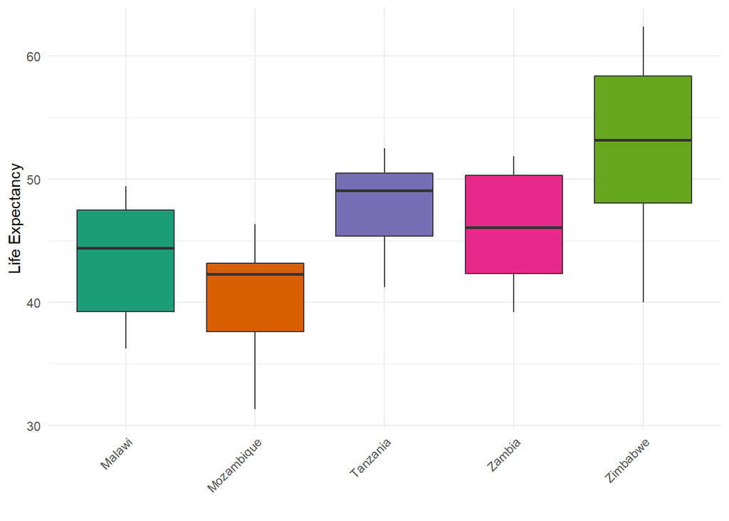

```r
malawi_long <- malawi_long %>% mutate(country = as_factor(country))

ggplot(malawi_long, aes(x = country, y = lifeExp, fill = country)) +
  geom_boxplot() + # make a boxplot
  labs(x = "", y = "Life Expectancy", fill = "Country") + # give the graph labels
  theme_minimal() + # change the theme
  scale_fill_brewer(palette = "Dark2") + # use a preset palette
  theme(axis.text.x= element_text(angle = 45, hjust = 1)) + # adjust the angle of the x axis text
  theme(legend.position = "none") + # move legend to the bottom
  guides(fill = guide_legend(nrow=2)) # give legend two rows
```

### Plots, plots, plots, plots, plots, plots, plots!

There are MANY different ways to visualize the same data:

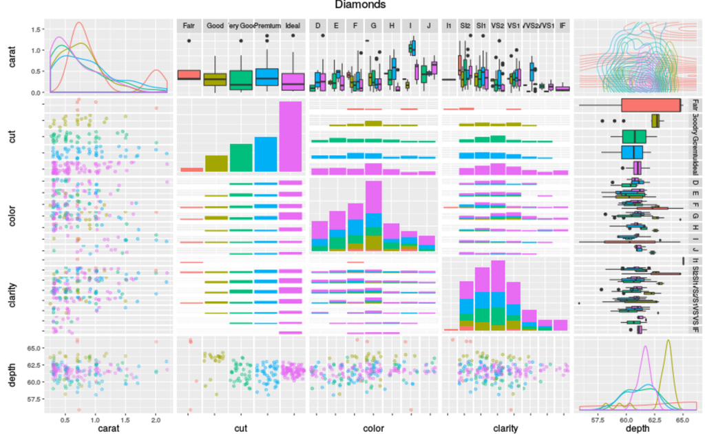

Thank you stackoverflow, for this viz of all the ways we could visualize data about diamonds!

… In the end we just have to choose the method that makes the most sense for our audience, our research questions, and our data!

Additionally, aRtists everywhere are using R to make ridiculously cool pieces of [generative](https://en.wikipedia.org/wiki/Generative_art) and patterned art. Check out some talented RLadies [here](https://ijeamaka-anyene.netlify.app/) and [here](https://djnavarro.net/projects/)! Plus, [#TidyTuesday](https://github.com/rfordatascience/tidytuesday) submissions can be [absolutely](https://tanyadoesscience.com/project/tidytuesday/), [wildly](https://martindevaux.com/2021/01/tidytuesday-art-collections/), [brilliantly](https://codingwithavery.com/posts/2020-08-12-tidy-tuesday-avatar/), good.

# Bonus

What’s *especially* neat about `ggplot2` is that it interfaces seamlessly with `sf`, a package for spatial data wrangling, analysis, and viz. `sf` treats its spatial objects as `data.frames` meaning…. we can use all of the magic & power of the `tidyverse` to play with the data! Plus, these data look just like any other data.frame, except attached to them is a column `geometry` that houses the coordinate information for the observation!

This is how we build the maps in our OSDS reports!

There are many, many ways to make maps beautiful maps in `ggplot` using `sf`. Anyone who says R isn’t built for spatial viz just hasn’t tried hard enough–check out [this](https://timogrossenbacher.ch/2019/04/bivariate-maps-with-ggplot2-and-sf/) if you don’t believe me (just about the most gorgeous, creative, and well-built map I’ve ever seen).

# Resources

- Emily Burchfield’s data viz materials, [here](https://www.emilyburchfield.org/courses/data_viz/intro_to_ggplot_tutorial).
- [Secrets of a happy graphing life](https://stat545.com/secrets.html).
- [The ggplot2 cheatsheet!](https://www.rstudio.com/wp-content/uploads/2015/03/ggplot2-cheatsheet.pdf)
- Chapters 5 - 12 in [this online textbook](https://clauswilke.com/dataviz/visualizing-amounts.html) provide a great overview of when to use different visualization strategies.